# Primer Parcial

## Teoría

### Punto 1

Un investigador esta interesado en estimar 𝐸[𝑌]. Sin embargo, una investigadora le sugiere que seria mejor estimar 𝐸[𝑌|𝑋]. Explque la diferencia de cada una de las metodologías y grafique.

El valor esperado de Y es la esperanza matemática, el promedio, sin tener en cuenta ninguna otra variable mas que los valores de Yi. En cambio 𝐸[𝑌|𝑋] es la esperanza dado x, es decir, toma en cuenta la relación que tiene Y con X, en nuestro caso para la función de regresión muestral
$$(*) Y=\beta_0+\beta_1 x+u$$
Sea Y=Consumo y X=Salario En el siguiente gráfico se ve que el consumo tiene una relación con el salario y el valor esperado del consumo en relación con el salario pasa por la recta (*). En cambio el promedio de consumo es 8

```r
x<-c(1,5,8,10,11,14)
y<-c(4,6,7,8,9,14)
datos=data.frame(x,y)
regressor=lm(y~x,data = datos)
plot(x,y)
abline(regressor)
```

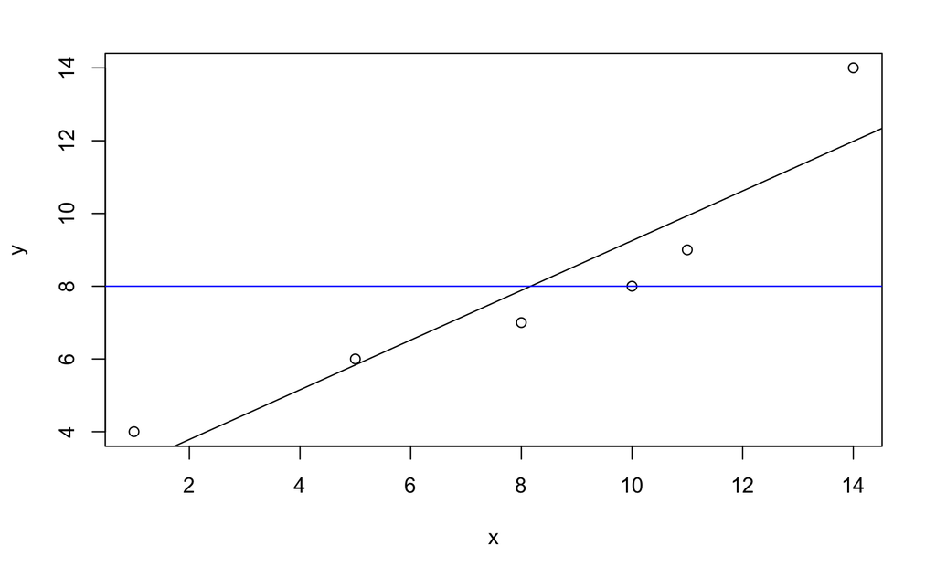

```r
abline(h=mean(y),col="blue")
```

### Punto 2)

¿Cuándo debería usar cada una de las fórmulas? Explique detalladamente y comente en que se diferencian.

$$(1)\hat\beta=\frac{\sum X*Y}{\sum X^2}$$
$$(2)\hat\beta=\frac{\sum(X - \bar X)(Y-\bar Y)}{\sum(X-\bar X)^2}$$
La fórmula (1) se refiere a una regresion lineal por el orgin. La fórmula (2) corresponde a la regresión lineal cuando tiene interceptor. El *beta* corresponde al calculo de la pendiente, en la formula (1) se utiliza cuando el modelo al que se quiere aproximar es una regresion por el origen. La diferencia con (2) es, como se ve, que no esta centrada. Normalmente, salvo que exista una buena explicación, se debe utilizar la formula (2)

### Punto 3

Desarrolle y comente la veracidad de la siguiente frase: “todas variables con relación estadística tienen su correlación causal”.

Falso. Correlación (la relación estadística) no implica causalidad, por ejemplo puedo tomar la variable libros comprados y tazas de leche llenas a la mitad en los bares de buenos aires, correr una regresión lineal, ver que R^2 es 0,80 y el p-value da 0.0001. Esto determina que están correlacionados. Ahora bien, cuál es la relación causal? A menos que los libros solo se vendan (o la mayoría de ellos se compran) en bares donde llenan a la mitad la tazas de leche difícilmente exista una relación causal. Este ejemplo muestra que, además de tener una relación estadística, debe existir un vector que vincule A con B de manera causal.

## Punto 4

4. Explique puntualmente que diferencia hay entre 𝛽^ y 𝛽. ¿Cuál es el fijo y cual el aleatorio? ¿Por qué? Relacione con insesgadez, eficiencia y consistencia.

𝛽^ (beta sombrero) es el estimador de beta que es el parámetro. Aca 𝛽^ es el aleatorio porque se usa con la muestra aleatoria y el parámetro es el fijo.

Insesgadez, eficiencia y consistencia son las 3 características de un estimador insesgado. Sicumple con esas caracterisitcas se puede decir que es un buen estimador, si es el de menor varianza, será MELI (en este caso que es una regresión lineal).

## Práctica

### Punto 1

#### Punto A

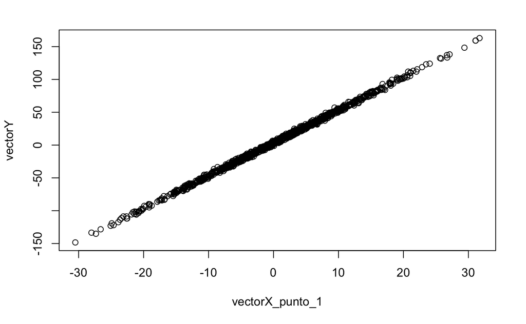

```r
library(stargazer)
vectorX_punto_1<-rnorm(1000,1,10)
vectorU<-rnorm(1000,0,2)
#Tomamos b0=3 y b1=5
vectorY<-3+5*vectorX_punto_1+vectorU # aca creo la fucion y le sumo el vector directamente.
#Nube de puntos del vector y,x
plot(vectorX_punto_1,vectorY)
```

```r
# Los puntos parecen seguir una funcion lineal
```

#### Punto B y C y d

```r
modelo_1<-lm(vectorY~vectorX_punto_1,data = datos)
plot(vectorX_punto_1,vectorY)
abline(modelo_1)
```

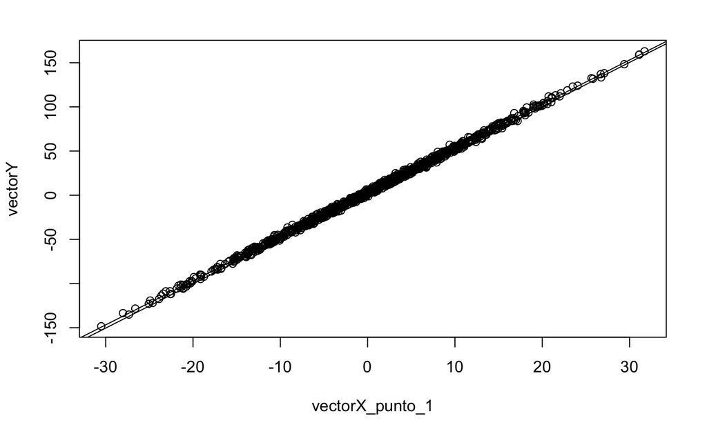

```r
modelo_2<-lm(vectorY~0+vectorX_punto_1,data = datos)
abline(modelo_2)
```

```r
#stargazer(modelo_1,type="text")
#stargazer(modelo_2,type="text")
```

Si se amplía se puede ver que son muy parecidas las rectas, lo que condice con que las pendientes son muy parecidas también.

```r
stargazer(modelo_1,modelo_2,type="text")
```

[output not shown]

```
=============================================================================
                                       Dependent variable:
                    ---------------------------------------------------------
                                             vectorY
                                (1)                          (2)
-----------------------------------------------------------------------------
vectorX_punto_1               4.999***                     5.015***
                              (0.006)                      (0.012)

Constant                      3.157***
                              (0.064)

-----------------------------------------------------------------------------
Observations                   1,000                        1,000
R2                             0.998                        0.995
Adjusted R2                    0.998                        0.995
Residual Std. Error       2.023 (df = 998)             3.747 (df = 999)
F Statistic         616,389.800*** (df = 1; 998) 181,227.100*** (df = 1; 999)
=============================================================================
Note:                                             *p<0.1; **p<0.05; ***p<0.01
```

#### Punto e

Si agregamos un vector con un conjunto de puntos con mayor desvío Y se va a volver más disperso, la recta ya no ajusta muy bien.

### Punto 2

Una empresa encuestó a la población para obtener que impacto tiene el ingreso en el consumo de su producto.
$$consumo=\beta_1+\beta_2*Salario+u_i$$
Interpretamos los parametros
$$\beta_1=145$$
eso significa que cuando el salario es 0 el consumo es 145. El parámetro:
$$\beta_1=0.63$$
es la pendiente, significa que por cada incremento en una unidad adicional del salario el consumo se incrementa en .63 unidades.

𝐶𝑜𝑛𝑠𝑢𝑚𝑜i5 = 𝐶𝑜𝑛𝑠𝑢𝑚𝑜i ∗ 5. Entiendo que en este punto esta cambiando la escala esta multiplicando por 5 todos los valores del consumo en este caso al multiplicar todos los valores de Y (consumo) por 5 se modifica b1 y b2 b1*=5*b1 y b2*=5*b2.